# CDA R notebook

Instructor: Partha Sarathi Mukherjee

Last updated: 2020-12-25 22:06:14

## (20/10/20) Introduction to GLM in R

### Logistic model on ungrouped data

Consider the following data, for illustration.

```r
x <- rep(0:2, each = 4)
s <- c(1, 0, 0, 0 , 1, 1, 0, 0, 1, 1, 1, 1)
print(rbind(x, s))
```

```
##   [,1] [,2] [,3] [,4] [,5] [,6] [,7] [,8] [,9] [,10] [,11] [,12]
## x    0    0    0    0    1    1    1    1    2     2     2     2
## s    1    0    0    0    1    1    0    0    1     1     1     1
```

Let us fit a logistic regression model:

```r
fit1 <- glm(s ~ x, family = binomial(link = logit))
summary(fit1)
```

```
##
## Call:
## glm(formula = s ~ x, family = binomial(link = logit))
##
## Deviance Residuals:
##     Min       1Q   Median       3Q      Max
## -1.4216  -0.6339   0.3752   0.5193   1.8459
##
## Coefficients:
##             Estimate Std. Error z value Pr(>|z|)
## (Intercept)   -1.503      1.181  -1.272   0.2033
## x              2.060      1.130   1.823   0.0682 .
## ---
## Signif. codes:  0 '***' 0.001 '**' 0.01 '*' 0.05 '.' 0.1 ' ' 1
##
## (Dispersion parameter for binomial family taken to be 1)
##
##     Null deviance: 16.301  on 11  degrees of freedom
## Residual deviance: 11.028  on 10  degrees of freedom
## AIC: 15.028
##
## Number of Fisher Scoring iterations: 4
```

Let us carefully understand each part of the summary.

- We can see the fitted coefficients, the corresponding standard error, z-score (estimate/std.error), and the p-value for testing that that particular coefficient is 0. A lower p-value indicates that that coefficient has a significant effect. The standard errors are just the square roots of the diagonal entries of the estimated var-cov matrix of the estimated parameters (see below).
- We also see the null-deviance, which is the deviance for the only-intercept model, and the residual deviance. The deviance of any model here is actually -2 loglikelihood of the model fit, since R takes the loglikelihood of the saturated model as 0 (see below).
- Our goal always is to reduce the residual deviance as much as possible, in exchange of as few degrees of freedom as possible. We loose (fit1$df.null - fit1$df.resid) many dfs for estimating the parameters in the model.

#### Estimated var-cov matrix

The estimated var-cov matrix of the estimated parameters can be found as:

```r
vcov(fit1)
```

```
##             (Intercept)         x
## (Intercept)    1.395404 -1.030746
## x             -1.030746  1.276810
```

#### What’s the saturated model taken by R?

Here we verify that the saturated model taken by R is indeed the model with perfect fit.

```r
x1 <- rep(0:1, each = 4)
x2 <- rep(0:1, times = 4)
y <- c(0, 1, 1, 0, 0, 1, 0, 1)
print(cbind(y, x1, x2))
```

```
##      y x1 x2
## [1,] 0  0  0
## [2,] 1  0  1
## [3,] 1  0  0
## [4,] 0  0  1
## [5,] 0  1  0
## [6,] 1  1  1
## [7,] 0  1  0
## [8,] 1  1  1
```

```r
summary(fit <- glm(y ~ x1 + x2, family = binomial))
```

```
##
## Call:
## glm(formula = y ~ x1 + x2, family = binomial)
##
## Deviance Residuals:
##       1        2        3        4        5        6        7        8
## -0.7585   0.7585   1.6651  -1.6651  -0.7585   0.7585  -0.7585   0.7585
##
## Coefficients:
##               Estimate Std. Error z value Pr(>|z|)
## (Intercept) -1.099e+00  1.414e+00  -0.777    0.437
## x1           3.984e-16  1.633e+00   0.000    1.000
## x2           2.197e+00  1.633e+00   1.346    0.178
##
## (Dispersion parameter for binomial family taken to be 1)
##
##     Null deviance: 11.0904  on 7  degrees of freedom
## Residual deviance:  8.9974  on 5  degrees of freedom
## AIC: 14.997
##
## Number of Fisher Scoring iterations: 4
```

```r
pi.hat = 1/(1 + exp(-fit$coef[1] - fit$coef[2]*x1 - fit$coef[3]*x2))
- 2 * sum(y * log(pi.hat) + (1 - y) * log(1 - pi.hat))
```

```
## [1] 8.997362
```

Note that it matches with the residual deviance given in the summary. Therefore, R takes the log-likelihood for the saturated model to be exactly 0.

#### Chi^2 test from deviances

To understand whether the model fit1 significantly better than the null model (only intercept), we perform a $\chi^2$ test with df = (fit1$df.null - fit1$df.resid).

```r
pchisq(fit1$null.deviance - fit1$deviance, fit1$df.null - fit1$df.resid, lower.tail = F)
```

```
## [1] 0.02166637
```

Since the p-value is low, we conclud that our model does significantly improve upon the null model.

### Logistic model on grouped data

```r
x <- c(0, 1, 2)
n <- c(4, 4, 4)
s <- c(1, 2, 4)

fit2 <- glm(cbind(s, n-s) ~ x, family = binomial(link = "logit"))
summary(fit2)
```

```
##
## Call:
## glm(formula = cbind(s, n - s) ~ x, family = binomial(link = "logit"))
##
## Deviance Residuals:
##       1        2        3
##  0.3377  -0.5543   0.7504
##
## Coefficients:
##             Estimate Std. Error z value Pr(>|z|)
## (Intercept)   -1.503      1.181  -1.272   0.2034
## x              2.060      1.130   1.823   0.0683 .
## ---
## Signif. codes:  0 '***' 0.001 '**' 0.01 '*' 0.05 '.' 0.1 ' ' 1
##
## (Dispersion parameter for binomial family taken to be 1)
##
##     Null deviance: 6.2568  on 2  degrees of freedom
## Residual deviance: 0.9844  on 1  degrees of freedom
## AIC: 8.6722
##
## Number of Fisher Scoring iterations: 4
```

Let us compare the above model (fit2) with the previous model (fit1).

```r
summary(fit1)
```

```
##
## Call:
## glm(formula = s ~ x, family = binomial(link = logit))
##
## Deviance Residuals:
##     Min       1Q   Median       3Q      Max
## -1.4216  -0.6339   0.3752   0.5193   1.8459
##
## Coefficients:
##             Estimate Std. Error z value Pr(>|z|)
## (Intercept)   -1.503      1.181  -1.272   0.2033
## x              2.060      1.130   1.823   0.0682 .
## ---
## Signif. codes:  0 '***' 0.001 '**' 0.01 '*' 0.05 '.' 0.1 ' ' 1
##
## (Dispersion parameter for binomial family taken to be 1)
##
##     Null deviance: 16.301  on 11  degrees of freedom
## Residual deviance: 11.028  on 10  degrees of freedom
## AIC: 15.028
##
## Number of Fisher Scoring iterations: 4
```

Note that the estimates and std errors etc. are same, but the deviances are changed, because the saturated model is different. However, the difference (null dev - resid dev) is same as before.

### Overdispersion situations

Overdispersed proportions modelled using Quasi-binomial. Here phi is not specified to be 1 apriori.

```r
fit3 <- glm(cbind(s,n-s) ~ x, family = quasibinomial(link = "logit"))
summary(fit3)
```

```
##
## Call:
## glm(formula = cbind(s, n - s) ~ x, family = quasibinomial(link = "logit"))
##
## Deviance Residuals:
##       1        2        3
##  0.3377  -0.5543   0.7504
##
## Coefficients:
##             Estimate Std. Error t value Pr(>|t|)
## (Intercept)  -1.5027     1.0129  -1.484    0.378
## x             2.0605     0.9689   2.127    0.280
##
## (Dispersion parameter for quasibinomial family taken to be 0.7351306)
##
##     Null deviance: 6.2568  on 2  degrees of freedom
## Residual deviance: 0.9844  on 1  degrees of freedom
## AIC: NA
##
## Number of Fisher Scoring iterations: 4
```

Also note that the estimates did not change between fit1, fit2 and fit3.

Similarly, overdispersed counts are modelled using quasipoisson.

### Comparing logit and probit links

Let us compare what happens when we apply both the logistic model and probit model on the same data.

```r
n = 40
x <- sort(runif(n, 0, 2))
y <- c(rep(0, n/4), sample(rep(0:1, c(n/4, n/4)), n/2, replace = T), rep(1, n/4))

logit.fit <- glm(y ~ x, family = binomial(link = logit))
print(summary(logit.fit))
```

```
##
## Call:
## glm(formula = y ~ x, family = binomial(link = logit))
##
## Deviance Residuals:
##     Min       1Q   Median       3Q      Max
## -1.8728  -0.5719   0.2484   0.6690   1.7266
##
## Coefficients:
##             Estimate Std. Error z value Pr(>|z|)
## (Intercept)  -2.3837     0.8229  -2.897  0.00377 **
## x             2.9985     0.9297   3.225  0.00126 **
## ---
## Signif. codes:  0 '***' 0.001 '**' 0.01 '*' 0.05 '.' 0.1 ' ' 1
##
## (Dispersion parameter for binomial family taken to be 1)
##
##     Null deviance: 55.352  on 39  degrees of freedom
## Residual deviance: 36.954  on 38  degrees of freedom
## AIC: 40.954
##
## Number of Fisher Scoring iterations: 5
```

```r
probit.fit <- glm(y ~ x, family = binomial(link = probit))
print(summary(probit.fit))
```

```
##
## Call:
## glm(formula = y ~ x, family = binomial(link = probit))
##
## Deviance Residuals:
##     Min       1Q   Median       3Q      Max
## -1.8717  -0.5521   0.1892   0.6717   1.7407
##
## Coefficients:
##             Estimate Std. Error z value Pr(>|z|)
## (Intercept)  -1.4757     0.4579  -3.223 0.001269 **
## x             1.8354     0.5010   3.664 0.000249 ***
## ---
## Signif. codes:  0 '***' 0.001 '**' 0.01 '*' 0.05 '.' 0.1 ' ' 1
##
## (Dispersion parameter for binomial family taken to be 1)
##
##     Null deviance: 55.352  on 39  degrees of freedom
## Residual deviance: 36.511  on 38  degrees of freedom
## AIC: 40.511
##
## Number of Fisher Scoring iterations: 6
```

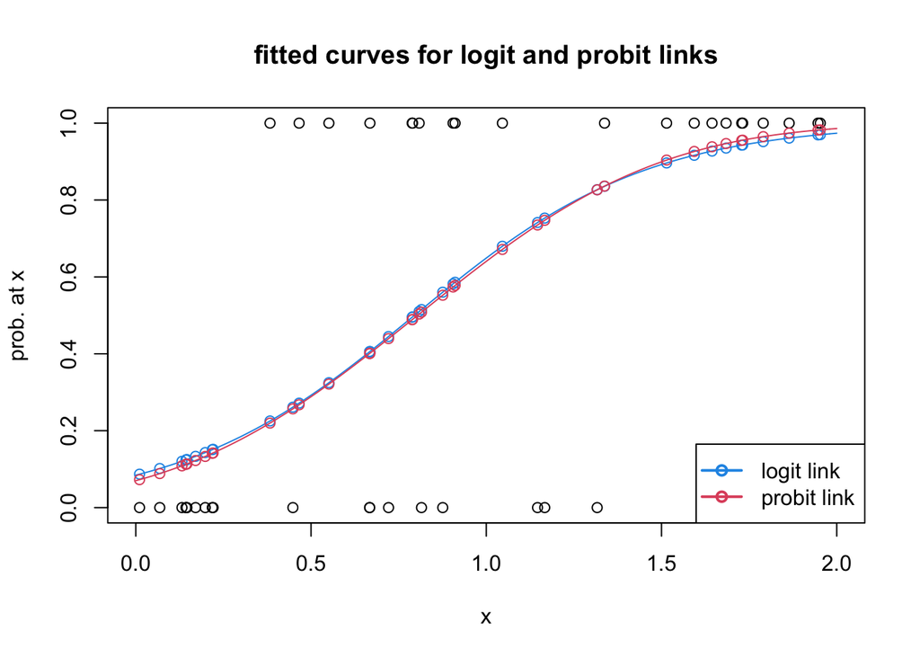

```r
curve(1/(1 + exp(-logit.fit$coef[1] - logit.fit$coef[2]*x)), xlim = c(floor(min(x)), floor(max(x)+1)), ylim = c(0, 1), col = 4, ylab = "prob. at x")
points(x, y, col = 1)
points(x, fitted(logit.fit), col = 4)
curve(pnorm(probit.fit$coef[1] + probit.fit$coef[2]*x), xlim = c(floor(min(x)), floor(max(x)+1)), ylim = c(0, 1), col = 2, add = T)
title(main = "fitted curves for logit and probit links")
points(x, fitted(probit.fit), col = 2)
legend("bottomright", legend = c("logit link", "probit link"), col = c(4, 2), lwd = 2, pch = 1)
```

Note that the deviances or the AIC values are almost same in this example.

## (03/11/20) Model Selection and Residuals

### Subset selection using step() function

Once again, we first create a toy data.

```r
y <- rep(1:0, each = 5)
x1 <- c(2, 3, 3, 4, 2, 1, 0, 3, 1, 0)
x2 <- rnorm(10)
print(rbind(y, x1, x2), digits = 2)
```

```
##    [,1] [,2] [,3] [,4] [,5] [,6] [,7]  [,8]  [,9] [,10]
## y   1.0 1.00 1.00 1.00  1.0 0.00  0.0  0.00  0.00  0.00
## x1  2.0 3.00 3.00 4.00  2.0 1.00  0.0  3.00  1.00  0.00
## x2  1.5 0.27 0.76 0.58 -1.3 0.75  1.6 -0.47 -0.16 -0.48
```

Here we know for sure that x2 is not significant, just a random quantity indept. of y and x1.

We fit the full model (with all predictors) and the null model (with only the intercept).

```r
full <- glm(y ~ x1 + x2, family = binomial(logit))
null <- glm(y ~ 1, family = binomial(logit))
```

It is possible that while fitting the full model, we get an warning saying that “glm.fit: fitted probabilities numerically 0 or 1 occurred”. If so, just simulate x2 once again!

Let us look at the summary of the above two models.

```r
summary(full)
```

```
##
## Call:
## glm(formula = y ~ x1 + x2, family = binomial(logit))
##
## Deviance Residuals:
##      Min        1Q    Median        3Q       Max
## -1.85251  -0.50808  -0.00328   0.53158   1.42025
##
## Coefficients:
##             Estimate Std. Error z value Pr(>|z|)
## (Intercept)  -3.4192     2.1688  -1.577   0.1149
## x1            1.7128     0.9765   1.754   0.0794 .
## x2            0.4313     0.9251   0.466   0.6411
## ---
## Signif. codes:  0 '***' 0.001 '**' 0.01 '*' 0.05 '.' 0.1 ' ' 1
##
## (Dispersion parameter for binomial family taken to be 1)
##
##     Null deviance: 13.8629  on 9  degrees of freedom
## Residual deviance:  7.8092  on 7  degrees of freedom
## AIC: 13.809
##
## Number of Fisher Scoring iterations: 5
```

```r
summary(null)
```

```
##
## Call:
## glm(formula = y ~ 1, family = binomial(logit))
##
## Deviance Residuals:
##    Min      1Q  Median      3Q     Max
## -1.177  -1.177   0.000   1.177   1.177
##
## Coefficients:
##               Estimate Std. Error z value Pr(>|z|)
## (Intercept) -4.915e-16  6.325e-01       0        1
##
## (Dispersion parameter for binomial family taken to be 1)
##
##     Null deviance: 13.863  on 9  degrees of freedom
## Residual deviance: 13.863  on 9  degrees of freedom
## AIC: 15.863
##
## Number of Fisher Scoring iterations: 2
```

Note that for the null model the null and residual deviances should be same, as expected.

Next, we do a subset regression: choosing the best subset using forward, backward, or the stepwise method.

#### Forward selection

```r
forward = step(null,
                scope = list(lower = formula(null), upper = formula(full)),
                direction = "forward")
```

```
## Start:  AIC=15.86
## y ~ 1
##
##        Df Deviance    AIC
## + x1    1   8.0341 12.034
## <none>     13.8629 15.863
## + x2    1  13.8158 17.816
##
## Step:  AIC=12.03
## y ~ x1
##
##        Df Deviance    AIC
## <none>      8.0341 12.034
## + x2    1   7.8092 13.809
```

#### Backward selection

The backward selection method: Here we have to start with the full model.

```r
backward = step(full,
                 scope = list(lower = formula(null), upper = formula(full)),
                 direction = "backward")
```

```
## Start:  AIC=13.81
## y ~ x1 + x2
##
##        Df Deviance    AIC
## - x2    1   8.0341 12.034
## <none>      7.8092 13.809
## - x1    1  13.8158 17.816
##
## Step:  AIC=12.03
## y ~ x1
##
##        Df Deviance    AIC
## <none>      8.0341 12.034
## - x1    1  13.8629 15.863
```

Here a predictor present in the model is excluded in the next step if that exclusion decreases the AIC.

#### Using BIC instead of AIC

```r
backward.BIC = step(full,
                scope = list(lower = formula(null), upper = formula(full)),
                direction = "backward", k = log(10))
```

```
## Start:  AIC=14.72
## y ~ x1 + x2
##
##        Df Deviance    AIC
## - x2    1   8.0341 12.639
## <none>      7.8092 14.717
## - x1    1  13.8158 18.421
##
## Step:  AIC=12.64
## y ~ x1
##
##        Df Deviance    AIC
## <none>      8.0341 12.639
## - x1    1  13.8629 16.166
```

#### Stepwise selection

```r
both.BIC = step(null,
                scope = list(lower = formula(null), upper = formula(full)),
                direction = "both", k = log(10))
```

```
## Start:  AIC=16.17
## y ~ 1
##
##        Df Deviance    AIC
## + x1    1   8.0341 12.639
## <none>     13.8629 16.166
## + x2    1  13.8158 18.421
##
## Step:  AIC=12.64
## y ~ x1
##
##        Df Deviance    AIC
## <none>      8.0341 12.639
## + x2    1   7.8092 14.717
## - x1    1  13.8629 16.166
```

#### Printing the chosen models

```r
formula(forward)
```

```
## y ~ x1
```

```r
backward
```

```
##
## Call:  glm(formula = y ~ x1, family = binomial(logit))
##
## Coefficients:
## (Intercept)           x1
##      -3.230        1.664
##
## Degrees of Freedom: 9 Total (i.e. Null);  8 Residual
## Null Deviance:       13.86
## Residual Deviance: 8.034     AIC: 12.03
```

```r
summary(backward.BIC)
```

```
##
## Call:
## glm(formula = y ~ x1, family = binomial(logit))
##
## Deviance Residuals:
##      Min        1Q    Median        3Q       Max
## -1.96014  -0.53159  -0.01283   0.56276   1.13593
##
## Coefficients:
##             Estimate Std. Error z value Pr(>|z|)
## (Intercept)  -3.2303     2.1264  -1.519   0.1287
## x1            1.6644     0.9643   1.726   0.0843 .
## ---
## Signif. codes:  0 '***' 0.001 '**' 0.01 '*' 0.05 '.' 0.1 ' ' 1
##
## (Dispersion parameter for binomial family taken to be 1)
##
##     Null deviance: 13.8629  on 9  degrees of freedom
## Residual deviance:  8.0341  on 8  degrees of freedom
## AIC: 12.034
##
## Number of Fisher Scoring iterations: 5
```

Note that backward.BIC does not print the BIC, it still prints the AIC. To print the BIC, we have to do this:

```r
backward.BIC$aic - (2 - log(10)) * backward.BIC$rank
```

```
## [1] 12.63925
```

#### The default direction is backward

```r
step(null)
```

```
## Start:  AIC=15.86
## y ~ 1
```

```
##
## Call:  glm(formula = y ~ 1, family = binomial(logit))
##
## Coefficients:
## (Intercept)
##  -4.915e-16
##
## Degrees of Freedom: 9 Total (i.e. Null);  9 Residual
## Null Deviance:       13.86
## Residual Deviance: 13.86     AIC: 15.86
```

#### Hiding the intermediate steps

Setting trace = 0 hides the intermediate steps.

```r
step(full, trace = 0)
```

```
##
## Call:  glm(formula = y ~ x1, family = binomial(logit))
##
## Coefficients:
## (Intercept)           x1
##      -3.230        1.664
##
## Degrees of Freedom: 9 Total (i.e. Null);  8 Residual
## Null Deviance:       13.86
## Residual Deviance: 8.034     AIC: 12.03
```

### Different types of residuals

```r
residuals(full, type = "pearson")
```

```
##          1          2          3          4          5          6          7
##  0.7186257  0.3997805  0.3592062  0.1584976  1.3197165 -0.5008626 -0.2547620
##          8          9         10
## -2.1357955 -0.4114035 -0.1632216
```

```r
residuals(full, type = "deviance")
```

```
##          1          2          3          4          5          6          7
##  0.9125286  0.5445524  0.4926623  0.2227605  1.4202539 -0.6690799 -0.3546388
##          8          9         10
## -1.8525063 -0.5592226 -0.2293145
```

```r
sum(residuals(full, type = "pearson")^2)   # gives Pearson's X^2
```

```
## [1] 7.645333
```

```r
sum(residuals(full, type = "deviance")^2)  # gives Likelihood statistic G^2
```

```
## [1] 7.809237
```

```r
deviance(full)      # this also gives Likelihood statistic G^2
```

```
## [1] 7.809237
```

## (05/11/20) Fitted values, Cook’s distance etc.

Here are two useful links: https://data.princeton.edu/wws509/r/c3s8 https://maths-people.anu.edu.au/~johnm/courses/r/ASC2008/pdf/glm-ohp.pdf

We will work with the additive model of contraceptive use by age, education, and desire for more children, which we know to be inadequate.

```r
cuse = read.table("https://data.princeton.edu/wws509/datasets/cuse.dat", header = TRUE)
head(cuse)
```

```
##     age education wantsMore notUsing using
## 1   <25       low       yes       53     6
## 2   <25       low        no       10     4
## 3   <25      high       yes      212    52
## 4   <25      high        no       50    10
## 5 25-29       low       yes       60    14
## 6 25-29       low        no       19    10
```

```r
additive <- glm(cbind(using, notUsing) ~ age + education + wantsMore,
                family = binomial, data = cuse)
summary(additive)
```

```
##
## Call:
## glm(formula = cbind(using, notUsing) ~ age + education + wantsMore,
##     family = binomial, data = cuse)
##
## Deviance Residuals:
##     Min       1Q   Median       3Q      Max
## -2.5148  -0.9376   0.2408   0.9822   1.7333
##
## Coefficients:
##              Estimate Std. Error z value Pr(>|z|)
## (Intercept)   -0.8082     0.1590  -5.083 3.71e-07 ***
## age25-29       0.3894     0.1759   2.214  0.02681 *
## age30-39       0.9086     0.1646   5.519 3.40e-08 ***
## age40-49       1.1892     0.2144   5.546 2.92e-08 ***
## educationlow  -0.3250     0.1240  -2.620  0.00879 **
## wantsMoreyes  -0.8330     0.1175  -7.091 1.33e-12 ***
## ---
## Signif. codes:  0 '***' 0.001 '**' 0.01 '*' 0.05 '.' 0.1 ' ' 1
##
## (Dispersion parameter for binomial family taken to be 1)
##
##     Null deviance: 165.772  on 15  degrees of freedom
## Residual deviance:  29.917  on 10  degrees of freedom
## AIC: 113.43
##
## Number of Fisher Scoring iterations: 4
```

Let us look at a few things we did not discuss earlier.

### Leverage and Influence

Pregibon extended regression diagnostics to GLMs and introduced a weighted hat matrix. The diagonal elements or leverages can be calculated with hatvalues() and Cook’s distance with cooks.distance. (Don’t be surprised if these look like the same functions we used for linear models. Like many other R functions, these are generic functions; R looks at the class of the object and calls the appropriate function, depending on whether the object is a linear model fitted by lm() or a generalized linear model fitted by glm().)

Let us calculate these diagnostics and list the groups that have potential and/or actual influence on the fit.

```r
print(pfit <- fitted(additive)) # these are the pi_i hats.
```

```
##         1         2         3         4         5         6         7         8
## 0.1228009 0.2435683 0.1623053 0.3082699 0.1712509 0.3221665 0.2223899 0.3967948
##         9        10        11        12        13        14        15        16
## 0.2577768 0.4440846 0.3246329 0.5250773 0.3149818 0.5140024 0.3889006 0.5941188
```

```r
print(lev <- hatvalues(additive)) # these are the h_i's
```

```
##          1          2          3          4          5          6          7
## 0.18808911 0.09028272 0.66963318 0.32345149 0.26167700 0.17312242 0.57748109
##          8          9         10         11         12         13         14
## 0.43196406 0.43738199 0.54229435 0.51981790 0.50609449 0.26997478 0.56014460
##         15         16
## 0.13551473 0.31307609
```

```r
print(cd <- cooks.distance(additive)) # Cook's distances
```

```
##           1           2           3           4           5           6
## 0.011602728 0.002454086 2.385867366 0.664492362 0.013423316 0.002877891
##           7           8           9          10          11          12
## 0.843656898 0.915463047 0.159079871 1.176022180 0.547727894 0.017020337
##          13          14          15          16
## 0.456263233 0.002054933 0.025113832 0.317098518
```

We have to be careful whenever Cook’s distance is greater than 1.

```r
pobs <- cuse$using/(cuse$using + cuse$notUsing) # sample proportions
i <- order(-lev)
cbind(cuse[, c("age", "education", "wantsMore")], pobs, pfit, lev, cd)[i[1:5],]
```

```
##      age education wantsMore      pobs      pfit       lev          cd
## 3    <25      high       yes 0.1969697 0.1623053 0.6696332 2.385867366
## 7  25-29      high       yes 0.2583732 0.2223899 0.5774811 0.843656898
## 14 40-49       low        no 0.5106383 0.5140024 0.5601446 0.002054933
## 10 30-39       low        no 0.5095541 0.4440846 0.5422943 1.176022180
## 11 30-39      high       yes 0.2804878 0.3246329 0.5198179 0.547727894
```

The three cells with potentially the largest influence in the fit are young women with some education who want more children, and older women with no education who want no more children. The youngest group had the most influence on the fit, whereas older uneducated women had no actual influence at all, with a Cook’s distance of zero.

Note: Cook’s distance is calculated using Pregibon’s one-step approximation, as described on page 49 of the notes. In short, it doesn’t refit the model excluding an observation, but takes just one-step in the IRLS algorithm, starting from the full sample mle.

### Standardized Residuals

The values of the (weighed) hat matrix can be used to compute standardized Pearson and deviance residuals, just as we did in linear models. These residuals take into account differences in residual variances originating from both the outcome and the fit.

```r
pr <- residuals(additive, "pearson") # Pearson's residuals
dr <- residuals(additive) # default: deviance residuals
spr <- pr/sqrt(1-lev)
sdr <- dr/sqrt(1-lev)
i <- order(-spr^2)
cbind(cuse[,c("age","education","wantsMore")], pobs, pfit, spr, sdr)[i[1:5],]
```

```
##      age education wantsMore      pobs      pfit       spr       sdr
## 4    <25      high        no 0.1666667 0.3082699 -2.887789 -3.057406
## 13 40-49       low       yes 0.1463415 0.3149818 -2.720763 -2.915930
## 8  25-29      high        no 0.2934783 0.3967948 -2.687572 -2.740228
## 3    <25      high       yes 0.1969697 0.1623053  2.657532  2.587927
## 10 30-39       low        no 0.5095541 0.4440846  2.440389  2.431919
```

We identify the same three observations picked up by the conventional residuals, but the absolute values are now closer to three, highlighting the lack of fit of these groups.

### Goodness of Fit

For **Hosmer-Lemeshow** chi-squared test to check the goodness of fit of a logistic regression model, see the bottom of this web-page: https://data.princeton.edu/wws509/r/c3s8. Small p-value indiactes that there are evidences of lack of fit.

## (06/11/20) ROC curve, complete and quasi-complete separations

### ROC curve

We will use the Default dataset available in **ISLR** package.

```r
library(ISLR)
library(tibble)
as_tibble(Default)
```

```
## # A tibble: 10,000 x 4
##    default student balance income
##    <fct>   <fct>     <dbl>  <dbl>
##  1 No      No         730. 44362.
##  2 No      Yes        817. 12106.
##  3 No      No        1074. 31767.
##  4 No      No         529. 35704.
##  5 No      No         786. 38463.
##  6 No      Yes        920.  7492.
##  7 No      No         826. 24905.
##  8 No      Yes        809. 17600.
##  9 No      No        1161. 37469.
## 10 No      No           0  29275.
## # … with 9,990 more rows
```

We select half of the data randomly as the test data and the remaining half as the test data.

```r
train.id = sample(nrow(Default), nrow(Default)/2)
default_train = Default[train.id, ]
default_test = Default[-train.id, ]
```

It is very reasonable that we estimate the model parameters using the training data, and apply the ROC curve on the test data to assess how the model performs on a fresh data. To get the ROC curve, we need the **pROC** package.

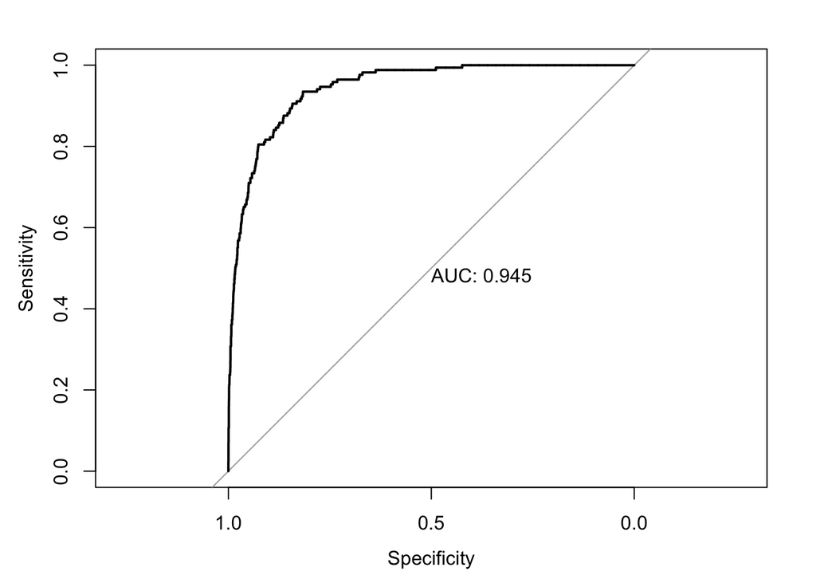

```r
library(pROC)
model_fit = glm(default ~ balance, data = default_train, family = "binomial")
test_prob = predict(model_fit, newdata = default_test, type = "response")
test_roc = roc(default_test$default ~ test_prob, plot = TRUE, print.auc = TRUE)
```

```r
as.numeric(test_roc$auc)
```

```
## [1] 0.9445997
```

A good model will have a high AUC, that is as often as possible a high sensitivity and specificity.

**A good reference:** (for Logistic Regression as a whole) https://daviddalpiaz.github.io/r4sl/logistic-regression.html

### Complete and quasi-complete separations

A simple function that I will use as a short cut:

```r
mylogistic.single<-function(x, y){
    fit <- glm(y ~ x, family = binomial(link = logit))
    print(summary(fit))
    curve(1/(1 + exp(-fit$coef[1] - fit$coef[2]*x)), xlim = c(floor(min(x)), floor(max(x)+1)), ylim = c(0, 1), ylab = "prob. at x", main = "fitted logistic curve")
    points(x, y, col = 2)
    points(x, fitted(fit), col = 4)
}
```

#### Complete separation

```r
n = 20
x <- sort(runif(n, 0, 2))
y <- c(rep(0, n/2), rep(1, n/2))
mylogistic.single(x, y)
```

```
## Warning: glm.fit: algorithm did not converge
```

```
## Warning: glm.fit: fitted probabilities numerically 0 or 1 occurred
```

```
##
## Call:
## glm(formula = y ~ x, family = binomial(link = logit))
##
## Deviance Residuals:
##        Min          1Q      Median          3Q         Max
## -4.447e-05  -2.100e-08   0.000e+00   2.100e-08   5.710e-05
##
## Coefficients:
##             Estimate Std. Error z value Pr(>|z|)
## (Intercept)   -573.3   287615.1  -0.002    0.998
## x              597.2   300184.3   0.002    0.998
##
## (Dispersion parameter for binomial family taken to be 1)
##
##     Null deviance: 2.7726e+01  on 19  degrees of freedom
## Residual deviance: 6.9417e-09  on 18  degrees of freedom
## AIC: 4
##
## Number of Fisher Scoring iterations: 25
```

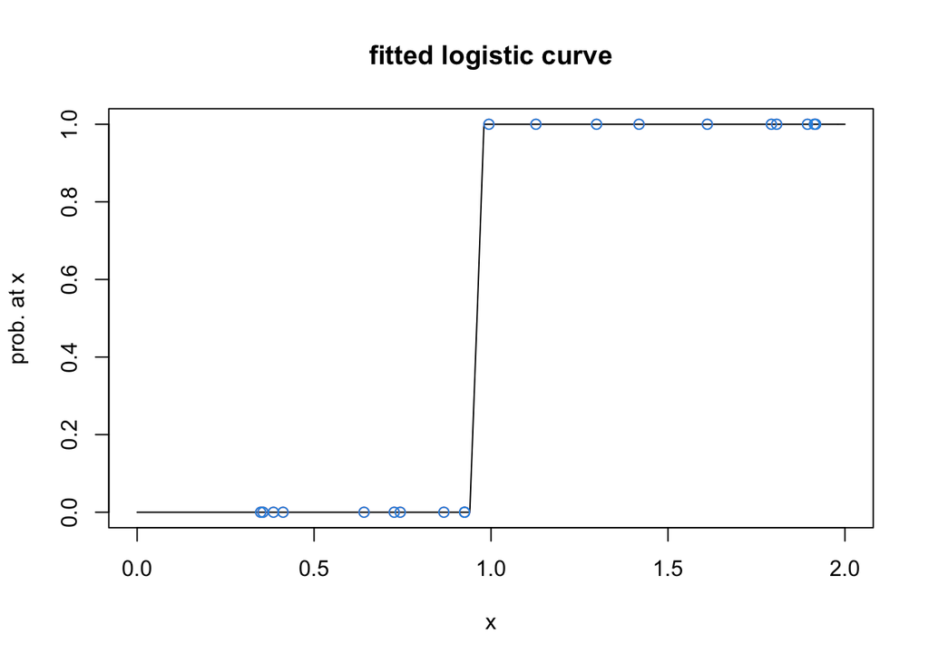

Note that the residual deviance is almost zero and the estimates and std. errors are so high. We also got several warnings.

#### Quasi-complete separation

```r
n = 20
x <- sort(c(runif(n/2, 0, 1), 1, 1, runif(n/2, 1, 2)))
y <- c(rep(0, n/2), 0, 1, rep(1, n/2))
mylogistic.single(x, y)
```

```
## Warning: glm.fit: fitted probabilities numerically 0 or 1 occurred
```

```
##
## Call:
## glm(formula = y ~ x, family = binomial(link = logit))
##
## Deviance Residuals:
##    Min      1Q  Median      3Q     Max
## -1.177   0.000   0.000   0.000   1.177
##
## Coefficients:
##             Estimate Std. Error z value Pr(>|z|)
## (Intercept)   -457.8   168399.3  -0.003    0.998
## x              457.8   168399.3   0.003    0.998
##
## (Dispersion parameter for binomial family taken to be 1)
##
##     Null deviance: 30.4985  on 21  degrees of freedom
## Residual deviance:  2.7726  on 20  degrees of freedom
## AIC: 6.7726
##
## Number of Fisher Scoring iterations: 24
```

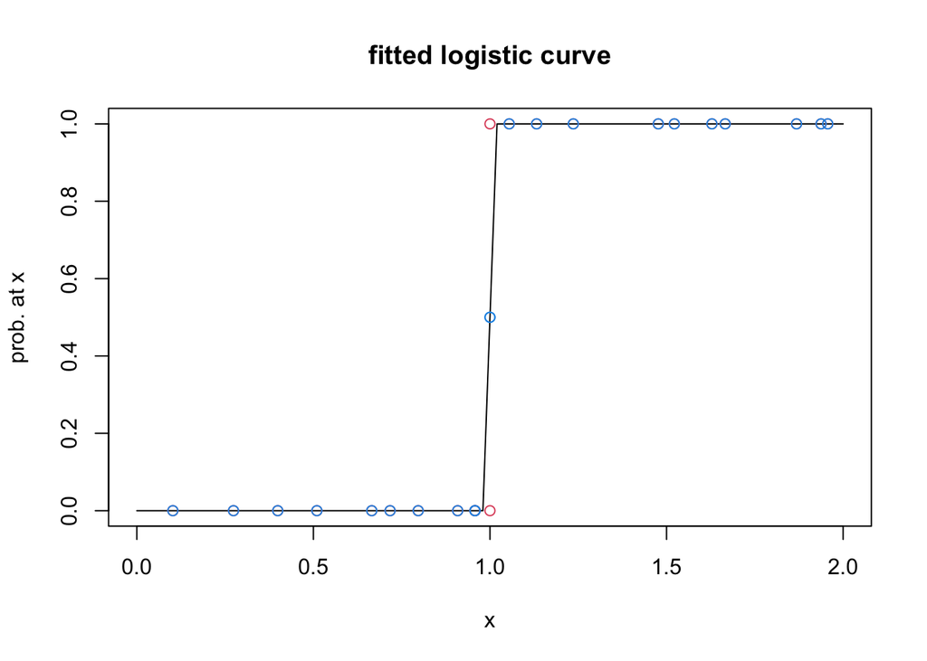

#### Usual case (neither of the above situations)

```r
n = 40
x <- sort(runif(n, 0, 2))
y <- c(rep(0, n/4), sample(rep(0:1, c(n/4, n/4)), n/2, replace = T), rep(1, n/4))
mylogistic.single(x, y)
```

```
##
## Call:
## glm(formula = y ~ x, family = binomial(link = logit))
##
## Deviance Residuals:
##     Min       1Q   Median       3Q      Max
## -1.9792  -0.3873   0.2825   0.4450   1.7484
##
## Coefficients:
##             Estimate Std. Error z value Pr(>|z|)
## (Intercept)   -3.915      1.250  -3.133 0.001729 **
## x              3.633      1.036   3.506 0.000455 ***
## ---
## Signif. codes:  0 '***' 0.001 '**' 0.01 '*' 0.05 '.' 0.1 ' ' 1
##
## (Dispersion parameter for binomial family taken to be 1)
##
##     Null deviance: 55.352  on 39  degrees of freedom
## Residual deviance: 29.345  on 38  degrees of freedom
## AIC: 33.345
##
## Number of Fisher Scoring iterations: 5
```

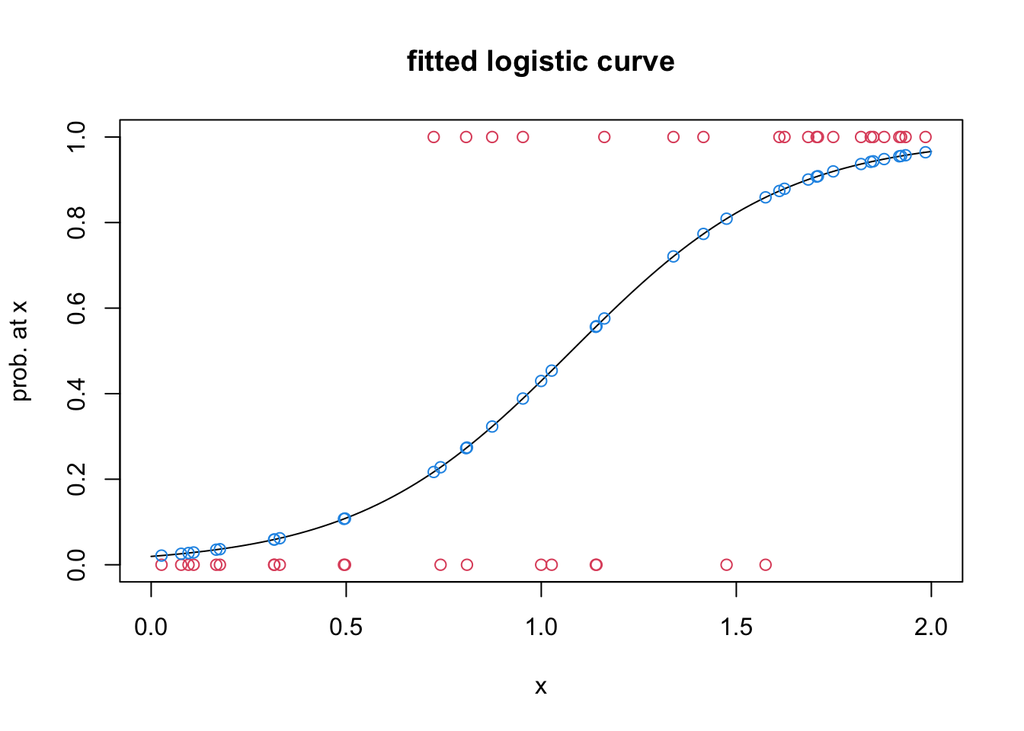

## (12/11/20) Log-linear models for multinomial responses

To fit multinomial log-linear models, we use the function *multinom* available in the **nnet** package. It fits multinomial log-linear models via neural networks.

```r
library(nnet)
# Lets create an artificial data:
y <- c(0, 0, 0, 1, 1, 1, 2, 2, 2) # so, y has 3 levels
x1 <- c(2, 3, 1, 7, 2, 0, -9, 6, 7)
x2 <- rnorm(9, mean = 0, sd = 1)
loglin.fit <- multinom(y ~ x1 + x2)
summary(loglin.fit)
```

```
## Call:
## multinom(formula = y ~ x1 + x2)
##
## Coefficients:
##   (Intercept)          x1         x2
## 1 -0.50451495  0.07201463 -1.7497469
## 2  0.03248512 -0.02588788 -0.1707496
##
## Std. Errors:
##   (Intercept)        x1       x2
## 1   1.1482795 0.2034021 2.271139
## 2   0.8783644 0.1664732 1.944030
##
## Residual Deviance: 18.78746
## AIC: 30.78746
```

```r
coef(loglin.fit)
```

```
##   (Intercept)          x1         x2
## 1 -0.50451495  0.07201463 -1.7497469
## 2  0.03248512 -0.02588788 -0.1707496
```

Note, a baseline category logit model was fitted above. The way to read the coefficients is that if the coefficients in the i-th row are $\beta_{i0}, \beta_{i1}, \beta_{i2},$ then the model was actually $\log(\Pr(y = i)/\Pr(y = 0)) = \beta_{i0} + \beta_{i1}\cdot x_1 + \beta_{i2}\cdot x_2.$

## (17/11/20) Models for ordinal responses

### Cumulative logit model

We use the **vglm** function in the **VGAM** package to fit a proportional odds cumulative logit model on the Pneumoconiosis in Coalminers Data, which is also available in the **VGAM** package. The pneumo data frame has 8 rows and 4 columns, exposure time is explanatory, and there are 3 ordinal response variables.

```r
library(VGAM)
pneumo
```

```
##   exposure.time normal mild severe
## 1           5.8     98    0      0
## 2          15.0     51    2      1
## 3          21.5     34    6      3
## 4          27.5     35    5      8
## 5          33.5     32   10      9
## 6          39.5     23    7      8
## 7          46.0     12    6     10
## 8          51.5      4    2      5
```

```r
pneumo <- transform(pneumo, lexptime = log(exposure.time))
# Fitting a proportional odds cumulative logit model
fit.cuml <- vglm(cbind(normal, mild, severe) ~ lexptime,
                  family = "propodds", data = pneumo)
summary(fit.cuml)
```

```
##
## Call:
## vglm(formula = cbind(normal, mild, severe) ~ lexptime, family = "propodds",
##     data = pneumo)
##
## Coefficients:
##               Estimate Std. Error z value Pr(>|z|)
## (Intercept):1  -9.6761     1.3241  -7.308 2.72e-13 ***
## (Intercept):2 -10.5817     1.3454  -7.865 3.69e-15 ***
## lexptime        2.5968     0.3811   6.814 9.50e-12 ***
## ---
## Signif. codes:  0 '***' 0.001 '**' 0.01 '*' 0.05 '.' 0.1 ' ' 1
##
## Names of linear predictors: logitlink(P[Y>=2]), logitlink(P[Y>=3])
##
## Residual deviance: 5.0268 on 13 degrees of freedom
##
## Log-likelihood: -25.0903 on 13 degrees of freedom
##
## Number of Fisher scoring iterations: 4
##
## Warning: Hauck-Donner effect detected in the following estimate(s):
## '(Intercept):1'
##
##
## Exponentiated coefficients:
## lexptime
## 13.42081
```

```r
coef(fit.cuml, matrix = TRUE)
```

```
##             logitlink(P[Y>=2]) logitlink(P[Y>=3])
## (Intercept)          -9.676093         -10.581725
## lexptime              2.596807           2.596807
```

### Adjacent category model

To illustrate this, we use a data set from the 2006 General Social Survey that shows the relationship in the United States between opinion about funding stem cell research and the fundamentalism/liberalism of one’s religious beliefs, stratified by gender.

First we store the counts in stemcell data in another form which will be suitable to us.

```r
library(brglm2)
library(tibble)
as_tibble(stemcell)
```

```
## # A tibble: 24 x 4
##    frequency research   gender religion
##        <dbl> <ord>      <fct>  <ord>
##  1        34 definitely female fundamentalist
##  2        41 definitely female moderate
##  3        58 definitely female liberal
##  4        21 definitely male   fundamentalist
##  5        30 definitely male   moderate
##  6        64 definitely male   liberal
##  7        67 probably   female fundamentalist
##  8        83 probably   female moderate
##  9        63 probably   female liberal
## 10        52 probably   male   fundamentalist
## # … with 14 more rows
```

```r
Dat = matrix(stemcell$frequency, ncol = 4)
colnames(Dat) = levels(stemcell$research)
gender = rep(1:0, each = 3)
religion = rep(1:3, times = 2)
print(Stemcell <- data.frame(religion, gender, Dat))
```

```
##   religion gender definitely probably probably.not definitely.not
## 1        1      1         34       67           30             25
## 2        2      1         41       83           23             14
## 3        3      1         58       63           15             12
## 4        1      0         21       52           24             15
## 5        2      0         30       52           18             11
## 6        3      0         64       50           16             11
```

Now let us fit the adjacent category model.

```r
fit.acat = vglm(Dat ~ religion + gender, data = Stemcell,
     family = "acat"(reverse = TRUE, parallel = TRUE))
# reverse = TRUE means we are going in the reverse order for the log-odds, and parallel = TRUE stands for prop odds, i.e., using same beta
summary(fit.acat)
```

```
##
## Call:
## vglm(formula = Dat ~ religion + gender, family = acat(reverse = TRUE,
##     parallel = TRUE), data = Stemcell)
##
## Coefficients:
##               Estimate Std. Error z value Pr(>|z|)
## (Intercept):1 -0.95090    0.14259  -6.669 2.58e-11 ***
## (Intercept):2  0.55734    0.14509   3.841 0.000122 ***
## (Intercept):3 -0.10656    0.16475  -0.647 0.517765
## religion       0.26681    0.04787   5.574 2.49e-08 ***
## gender        -0.01412    0.07671  -0.184 0.853953
## ---
## Signif. codes:  0 '***' 0.001 '**' 0.01 '*' 0.05 '.' 0.1 ' ' 1
##
## Names of linear predictors: loglink(P[Y=1]/P[Y=2]), loglink(P[Y=2]/P[Y=3]),
## loglink(P[Y=3]/P[Y=4])
##
## Residual deviance: 11.9972 on 13 degrees of freedom
##
## Log-likelihood: -48.0771 on 13 degrees of freedom
##
## Number of Fisher scoring iterations: 4
##
## No Hauck-Donner effect found in any of the estimates
```

```r
coef(fit.acat, matrix = TRUE)
```

```
##             loglink(P[Y=1]/P[Y=2]) loglink(P[Y=2]/P[Y=3])
## (Intercept)            -0.95089664             0.55733671
## religion                0.26681151             0.26681151
## gender                 -0.01412006            -0.01412006
##             loglink(P[Y=3]/P[Y=4])
## (Intercept)            -0.10655962
## religion                0.26681151
## gender                 -0.01412006
```

Let’s see what happens if we set reverse = FALSE.

```r
fit.acat2 = vglm(Dat ~ religion + gender, data = Stemcell,
     family = "acat"(reverse = FALSE, parallel = TRUE))
# reverse = TRUE means we are going in the reverse order for the log-odds, and parallel = TRUE stands for prop odds, i.e., using same beta
summary(fit.acat2)
```

```
##
## Call:
## vglm(formula = Dat ~ religion + gender, family = acat(reverse = FALSE,
##     parallel = TRUE), data = Stemcell)
##
## Coefficients:
##               Estimate Std. Error z value Pr(>|z|)
## (Intercept):1  0.95090    0.14259   6.669 2.58e-11 ***
## (Intercept):2 -0.55734    0.14509  -3.841 0.000122 ***
## (Intercept):3  0.10656    0.16475   0.647 0.517765
## religion      -0.26681    0.04787  -5.574 2.49e-08 ***
## gender         0.01412    0.07671   0.184 0.853953
## ---
## Signif. codes:  0 '***' 0.001 '**' 0.01 '*' 0.05 '.' 0.1 ' ' 1
##
## Names of linear predictors: loglink(P[Y=2]/P[Y=1]), loglink(P[Y=3]/P[Y=2]),
## loglink(P[Y=4]/P[Y=3])
##
## Residual deviance: 11.9972 on 13 degrees of freedom
##
## Log-likelihood: -48.0771 on 13 degrees of freedom
##
## Number of Fisher scoring iterations: 4
##
## No Hauck-Donner effect found in any of the estimates
```

Thus, setting reverse = FALSE means taking linear predictors: loglink(P[Y=2]/P[Y=1]), loglink(P[Y=3]/P[Y=2]), loglink(P[Y=4]/P[Y=3]). Whereas for reverse = TRUE we take the linear predictors: loglink(P[Y=1]/P[Y=2]), loglink(P[Y=2]/P[Y=3]), loglink(P[Y=3]/P[Y=4]).

### Continuation ratio model

We use the Stemcell data again.

```r
fit.cratio = vglm(Dat ~ religion + gender, data = Stemcell,
     family = "cratio"(reverse = TRUE, parallel = TRUE))
# reverse = TRUE means we are going in the reverse order for the log-odds, and parallel = TRUE stands for prop odds, i.e., using same beta
summary(fit.cratio)
```

```
##
## Call:
## vglm(formula = Dat ~ religion + gender, family = cratio(reverse = TRUE,
##     parallel = TRUE), data = Stemcell)
##
## Coefficients:
##               Estimate Std. Error z value Pr(>|z|)
## (Intercept):1 -1.26976    0.18490  -6.867 6.54e-12 ***
## (Intercept):2  0.77852    0.17753   4.385 1.16e-05 ***
## (Intercept):3  1.34284    0.18309   7.334 2.23e-13 ***
## religion       0.42160    0.06932   6.082 1.19e-09 ***
## gender        -0.03388    0.11211  -0.302    0.763
## ---
## Signif. codes:  0 '***' 0.001 '**' 0.01 '*' 0.05 '.' 0.1 ' ' 1
##
## Names of linear predictors: logitlink(P[Y<2|Y<=2]), logitlink(P[Y<3|Y<=3]),
## logitlink(P[Y<4|Y<=4])
##
## Residual deviance: 6.7109 on 13 degrees of freedom
##
## Log-likelihood: -45.4339 on 13 degrees of freedom
##
## Number of Fisher scoring iterations: 3
##
## No Hauck-Donner effect found in any of the estimates
```

```r
coef(fit.cratio, matrix = TRUE)
```

```
##             logitlink(P[Y<2|Y<=2]) logitlink(P[Y<3|Y<=3])
## (Intercept)             -1.2697574              0.7785208
## religion                 0.4216044              0.4216044
## gender                  -0.0338765             -0.0338765
##             logitlink(P[Y<4|Y<=4])
## (Intercept)              1.3428378
## religion                 0.4216044
## gender                  -0.0338765
```

#### If we wish to use non-proportional odds:

We use the Stemcell data again.

```r
fit.cratio.n = vglm(Dat ~ religion + gender, data = Stemcell,
     family = "cratio"(reverse = TRUE, parallel = FALSE))
summary(fit.cratio.n)
```

```
##
## Call:
## vglm(formula = Dat ~ religion + gender, family = cratio(reverse = TRUE,
##     parallel = FALSE), data = Stemcell)
##
## Coefficients:
##               Estimate Std. Error z value Pr(>|z|)
## (Intercept):1 -1.25608    0.26287  -4.778 1.77e-06 ***
## (Intercept):2  0.66621    0.27632   2.411 0.015909 *
## (Intercept):3  1.45226    0.31687   4.583 4.58e-06 ***
## religion:1     0.44297    0.10472   4.230 2.33e-05 ***
## religion:2     0.43282    0.12241   3.536 0.000406 ***
## religion:3     0.36729    0.14091   2.607 0.009146 **
## gender:1      -0.14117    0.16829  -0.839 0.401568
## gender:2       0.13015    0.19845   0.656 0.511918
## gender:3      -0.05235    0.22952  -0.228 0.819563
## ---
## Signif. codes:  0 '***' 0.001 '**' 0.01 '*' 0.05 '.' 0.1 ' ' 1
##
## Names of linear predictors: logitlink(P[Y<2|Y<=2]), logitlink(P[Y<3|Y<=3]),
## logitlink(P[Y<4|Y<=4])
##
## Residual deviance: 5.4118 on 9 degrees of freedom
##
## Log-likelihood: -44.7844 on 9 degrees of freedom
##
## Number of Fisher scoring iterations: 4
##
## No Hauck-Donner effect found in any of the estimates
```

```r
coef(fit.cratio.n, matrix = TRUE)
```

```
##             logitlink(P[Y<2|Y<=2]) logitlink(P[Y<3|Y<=3])
## (Intercept)             -1.2560774              0.6662095
## religion                 0.4429689              0.4328186
## gender                  -0.1411698              0.1301517
##             logitlink(P[Y<4|Y<=4])
## (Intercept)             1.45225937
## religion                0.36728869
## gender                 -0.05235495
```

Note that it gives three different slopes for both the attributes religion and gender.

## (27/11/20) Log-linear models

We use the following dataset to illustrate log-linear models.

```r
HairEyeColor
```

```
## , , Sex = Male
##
##        Eye
## Hair    Brown Blue Hazel Green
##   Black    32   11    10     3
##   Brown    53   50    25    15
##   Red      10   10     7     7
##   Blond     3   30     5     8
##
## , , Sex = Female
##
##        Eye
## Hair    Brown Blue Hazel Green
##   Black    36    9     5     2
##   Brown    66   34    29    14
##   Red      16    7     7     7
##   Blond     4   64     5     8
```

Note that it is essentially a 3-way table.

### Fitting the (XY, YZ, XZ) model

```r
loglin.pairwise <- loglin(table = HairEyeColor,
                          margin = list(c(1, 2), c(1, 3), c(2, 3)),
                          fit = TRUE) # fit = TRUE means we want to see the fitted values
```

```
## 5 iterations: deviation 0.04093795
```

```r
# margin = list(c(1, 2), c(1, 3), c(2, 3)) means we are using the (XY, YZ, XZ) model
loglin.pairwise$fit
```

```
## , , Sex = Male
##
##        Eye
## Hair        Brown      Blue     Hazel     Green
##   Black 32.789022 11.743604  8.443926  3.018481
##   Brown 52.523050 45.931148 28.195250 16.348213
##   Red   10.760485  8.819775  6.916602  7.502671
##   Blond  1.927443 34.505472  3.444222  6.130636
##
## , , Sex = Female
##
##        Eye
## Hair        Brown      Blue     Hazel     Green
##   Black 35.208836  8.258511  6.556304  1.981916
##   Brown 66.477232 38.072151 25.804202 12.652225
##   Red   15.239924  8.180608  7.083293  6.497414
##   Blond  5.074007 59.488731  6.556201  9.868446
```

```r
pchisq(loglin.pairwise$lrt, loglin.pairwise$df, lower.tail = FALSE)
```

```
## [1] 0.66196
```

Since the last p-value is high, we conclude that the model with pairwise interactions and no 3-factor interaction fits well.

### Fitting the (XY, Z) model

```r
loglin.xy.z <- loglin(table = HairEyeColor,
                          margin = list(c(1, 2), 3),
                          fit = TRUE) # fit = TRUE means we want to see the fitted values
```

```
## 2 iterations: deviation 5.684342e-14
```

```r
# margin = list(c(1, 2), 3) means we are using the (XY, Z) model
loglin.xy.z$fit
```

```
## , , Sex = Male
##
##        Eye
## Hair        Brown      Blue     Hazel     Green
##   Black 32.047297  9.425676  7.069257  2.356419
##   Brown 56.082770 39.587838 25.449324 13.667230
##   Red   12.253378  8.011824  6.597973  6.597973
##   Blond  3.298986 44.300676  4.712838  7.540541
##
## , , Sex = Female
##
##        Eye
## Hair        Brown      Blue     Hazel     Green
##   Black 35.952703 10.574324  7.930743  2.643581
##   Brown 62.917230 44.412162 28.550676 15.332770
##   Red   13.746622  8.988176  7.402027  7.402027
##   Blond  3.701014 49.699324  5.287162  8.459459
```

### Fitting the independence model

```r
loglin.x.y.z <- loglin(table = HairEyeColor,
                          margin = list(1, 2, 3),
                          fit = TRUE) # fit = TRUE means we want to see the fitted values
```

```
## 2 iterations: deviation 5.684342e-14
```

```r
# margin = list(1, 2, 3) means we are using the (X, Y, Z) model
loglin.x.y.z$fit
```

```
## , , Sex = Male
##
##        Eye
## Hair        Brown      Blue     Hazel     Green
##   Black 18.915038 18.485151  7.995903  5.502557
##   Brown 50.089824 48.951419 21.174335 14.571585
##   Red   12.434886 12.152275  5.256566  3.617421
##   Blond 22.242684 21.737168  9.402589  6.470599
##
## , , Sex = Female
##
##        Eye
## Hair        Brown      Blue     Hazel     Green
##   Black 21.220097 20.737822  8.970314  6.173119
##   Brown 56.193960 54.916825 23.754719 16.347334
##   Red   13.950249 13.633198  5.897151  4.058254
##   Blond 24.953262 24.386142 10.548424  7.259131
```